# Unit 8 activities

Guilherme Amorim

2024-10-16

```r
# initial setup
library(haven)
library(skimr)
library(tidyverse)
library(here)
Health_Data<-read_sav(here("Datasets/Health Data.sav"))
```

```python
# first install packages (from terminal)

# pip3 install numpy

# pip3 install pandas

# pip3 install matplotlib

# pip3 install pyreadstat

import pandas as pd

import numpy as np

import matplotlib.pyplot as plt

from scipy import stats


Health_Data_python = pd.read_spss("C:/Users/guilhermep/Documents/PgDip/Coding/Module 2/pgdip_module2_practice/Datasets/Health Data.sav")
```

# Unit 8 notes - non-parametric tests

## Mann-Whitney U (2 independent samples)

### R

Using Health data, we want to know whether the median systolic BP of males and females is same.

```r
wilcox.test(sbp~sex_1,Health_Data)
```

```
##
##  Wilcoxon rank sum test with continuity correction
##
## data:  sbp by sex_1
## W = 5705.5, p-value = 0.1682
## alternative hypothesis: true location shift is not equal to 0
```

p-value 0.1682, therefore the null hypothesis cannot be rejected and we conclude that there is no statistically significant difference in median systolic BP between males and females.

### Python

```python
stats.mannwhitneyu(Health_Data_python.sbp[Health_Data_python.sex=="Male"],Health_Data_python.sbp[Health_Data_python.sex=="Female"])
```

```
## MannwhitneyuResult(statistic=4535.5, pvalue=0.16823128740168025)
```

## Wilcoxon Signed Rank (2 paired samples)

“The null hypothesis focuses on that there is no change in the post-test scores compared to the pre-test score due to the training.”

### R

```r
wilcox.test(Health_Data$pre_test, Health_Data$post_test, exact = FALSE, paired = TRUE)
```

```
##
##  Wilcoxon signed rank test with continuity correction
##
## data:  Health_Data$pre_test and Health_Data$post_test
## V = 0, p-value = 8.288e-07
## alternative hypothesis: true location shift is not equal to 0
```

p-value <0.001, therefore we reject the null hypothesis and conclude that there is a statistically significant change in post-test scores compared to the pre-test score due to the training.

### Python

```python
stats.wilcoxon(Health_Data_python.pre_test.dropna(), Health_Data_python.post_test.dropna())
```

```
## WilcoxonResult(statistic=0.0, pvalue=4.656612873077393e-10)
```

## Kruskal-Wallis test (>2 paired or unpaired samples)

“The null hypothesis is that the systolic BP has the same central tendency across the religious groups. (There is no difference in rank sums).”

### R

```r
kruskal.test(sbp~religion, data = Health_Data)
```

```
##
##  Kruskal-Wallis rank sum test
##
## data:  sbp by religion
## Kruskal-Wallis chi-squared = 0.054144, df = 2, p-value = 0.9733
```

p-value >0.05, therefore we fail to reject the null hypothesis and conclude that there is no statistically significant difference in systolic BP across religious groups.

### Python

```python
stats.kruskal(Health_Data_python["sbp"][Health_Data_python["religion_2"]=="MUSLIM"], Health_Data_python["sbp"][Health_Data_python["religion_2"]=="HINDU"], Health_Data_python["sbp"][Health_Data_python["religion_2"]=="Christian"], Health_Data_python["sbp"][Health_Data_python["religion_2"]=="BUDDHISM"])
```

```
## KruskalResult(statistic=0.07881706485516941, pvalue=0.9942521768125786)
```

# Unit 8 - data activity

1. Compute mean, median and mode of variables sbp, dbp and income
2. Find out the five-figure summary of income variable and present it using a Boxplot
3. Run a suitable hypothesis test to see if there is any association between systolic blood pressure and presence and absence of peptic ulcer.

## R

```r
## Compute mean, median and mode of variables sbp, dbp and income

getmode <- function(v) {
   uniqv <- unique(v)
   uniqv[which.max(tabulate(match(v, uniqv)))]
}

Health_Data%>%
  select(sbp, dbp, income)%>%
  pivot_longer(c(sbp, dbp, income), values_to = "value", names_to = "variable")%>%
  group_by(variable)%>%
  summarise(mean=mean(value),
            median=median(value),
            mode=getmode(value))
```

```
## # A tibble: 3 × 4
##   variable    mean median  mode
##   <chr>      <dbl>  <dbl> <dbl>
## 1 dbp         82.8    82     80
## 2 income   85194.  86560. 79774
## 3 sbp        128.    123    120
```

```r
## Find out the five-figure summary of income variable and present it using a Boxplot

Health_Data%>%
  select(income)%>%
  summarise(min=min(income),
            Q1=quantile(income, 0.25),
            median=median(income),
            Q3=quantile(income, 0.75),
            max=max(income))
```

```
## # A tibble: 1 × 5
##     min     Q1 median     Q3    max
##   <dbl>  <dbl>  <dbl>  <dbl>  <dbl>
## 1 52933 68636. 86560. 99696. 117210
```

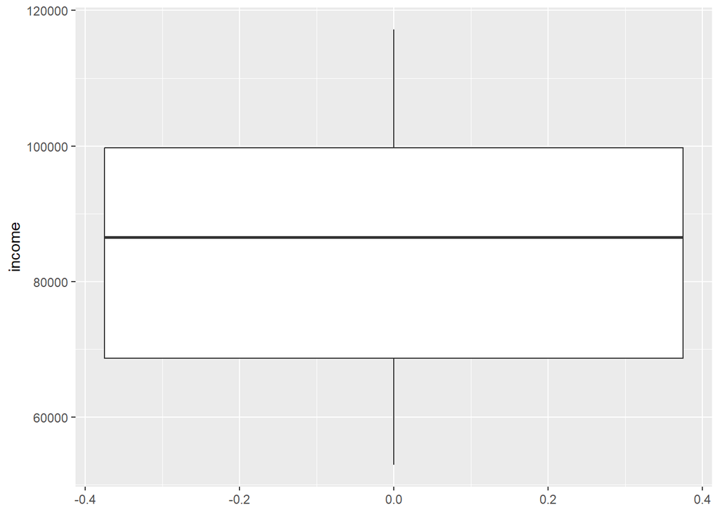

```r
Health_Data%>%
  ggplot(aes(income))+
  geom_boxplot()+
  coord_flip()
```

```r
## Run a suitable hypothesis test to see if there is any association between systolic blood pressure and presence and absence of peptic ulcer.

t.test(sbp~pepticulcer,data = Health_Data, var.equal=TRUE, alternative="less")
```

```
##
##  Two Sample t-test
##
## data:  sbp by pepticulcer
## t = 1.2772, df = 208, p-value = 0.8985
## alternative hypothesis: true difference in means between group 1 and group 2 is less than 0
## 95 percent confidence interval:
##      -Inf 10.21382
## sample estimates:
## mean in group 1 mean in group 2
##        131.3171        126.8639
```

p-value 0.8985, suggesting no statistically significant difference in systolic blood pressure between people with and without peptic ulcer

## Python

```python
## Compute mean, median and mode of variables sbp, dbp and income
"SBP:"
```

```
## 'SBP:'
```

```python
"Mean: "+ str(Health_Data_python["sbp"].mean())
```

```
## 'Mean: 127.73333333333333'
```

```python
"Median: " +  str(Health_Data_python["sbp"].median())
```

```
## 'Median: 123.0'
```

```python
"Mode: " + str(stats.mode(Health_Data_python["sbp"]).mode)
```

```
## 'Mode: 120.0'
```

```python
"DBP:"
```

```
## 'DBP:'
```

```python
"Mean: "+ str(Health_Data_python["dbp"].mean())
```

```
## 'Mean: 82.76666666666667'
```

```python
"Median: " +  str(Health_Data_python["dbp"].median())
```

```
## 'Median: 82.0'
```

```python
"Mode: " + str(stats.mode(Health_Data_python["dbp"]).mode)
```

```
## 'Mode: 74.0'
```

```python
"Income:"
```

```
## 'Income:'
```

```python
"Mean: "+ str(Health_Data_python["income"].mean())
```

```
## 'Mean: 85194.4857142857'
```

```python
"Median: " +  str(Health_Data_python["income"].median())
```

```
## 'Median: 86560.5'
```

```python
"Mode: " + str(stats.mode(Health_Data_python["income"]).mode)
```

```
## 'Mode: 52933.0'
```

```python
## Find out the five-figure summary of income variable and present it using a Boxplot
print("Min:", Health_Data_python["income"].min())
```

```
## Min: 52933.0
```

```python
print("Q1:", np.percentile(Health_Data_python["income"],0.25))
```

```
## Q1: 53195.295
```

```python
print("Median:", Health_Data_python["income"].median())
```

```
## Median: 86560.5
```

```python
print("Q3:", np.percentile(Health_Data_python["income"],0.75))
```

```
## Q3: 53742.0175
```

```python
print("Max:", Health_Data_python["income"].max())
```

```
## Max: 117210.0
```

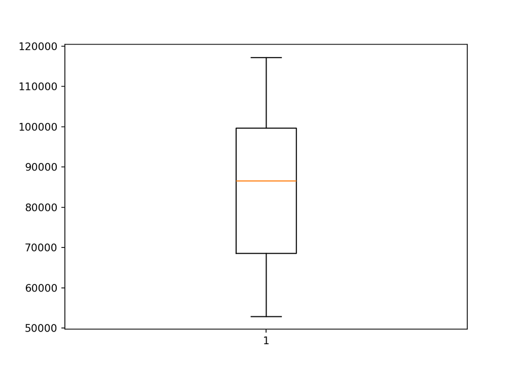

```python
fig = plt.boxplot(Health_Data_python["income"])
plt.show()
```

```python
## Run a suitable hypothesis test to see if there is any association between systolic blood pressure and presence and absence of peptic ulcer.

stats.ttest_ind(Health_Data_python["sbp"][Health_Data_python["pepticulcer"]=="Yes"],Health_Data_python["sbp"][Health_Data_python["pepticulcer"]=="No"])
```

```
## TtestResult(statistic=1.2772129020220484, pvalue=0.2029509444350035, df=208.0)
```

# Unit 8 - scenario-based exercise (95% confidence interval)

Now, find out the mean efficiency of each vendor and determine which vendor shows a higher significance of improvement in employee efficiency statistically at the 95% level.

## R

Visualise distributions

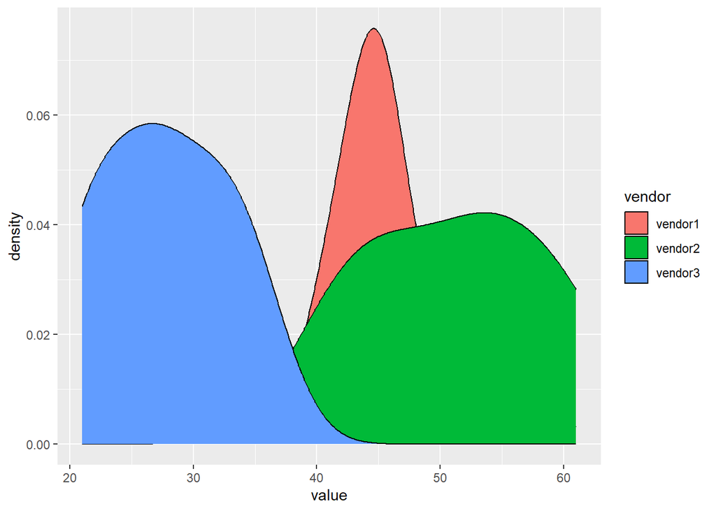

```r
# load data
library(readxl)
vendor_scores <- read_excel("~/PgDip/Coding/Module 2/pgdip_module2_practice/Datasets/vendor_scores.xlsx")

vendor_scores%>%
  pivot_longer(everything(), names_to = "vendor", values_to = "value")%>%
  ggplot(aes(value, fill=vendor))+
  geom_density()
```

Compute summary statistics

```r
vendor_scores%>%
  pivot_longer(everything(), names_to = "vendor", values_to = "value")%>%
  group_by(vendor)%>%
  summarise(mean=mean(value),
            sd=sd(value),
            conf_int=paste0(round(mean-1.98*sd,2), "-", round(mean+1.98*sd,2)))
```

```
## # A tibble: 3 × 4
##   vendor   mean    sd conf_int
##   <chr>   <dbl> <dbl> <chr>
## 1 vendor1  44.7  8.58 27.73-61.7
## 2 vendor2  51    7.33 36.5-65.5
## 3 vendor3  27.7  5.28 17.25-38.17
```

Compute ANOVA

```r
vendor_scores_pivoted<-vendor_scores%>%
  pivot_longer(everything(), names_to = "vendor", values_to = "value")

res.aov<-aov(value~vendor, data = vendor_scores_pivoted)
summary(res.aov)
```

```
##             Df Sum Sq Mean Sq F value   Pr(>F)
## vendor       2 2031.7  1015.9   19.64 2.98e-05 ***
## Residuals   18  930.9    51.7
## ---
## Signif. codes:  0 '***' 0.001 '**' 0.01 '*' 0.05 '.' 0.1 ' ' 1
```

## Python

Visualise distributions

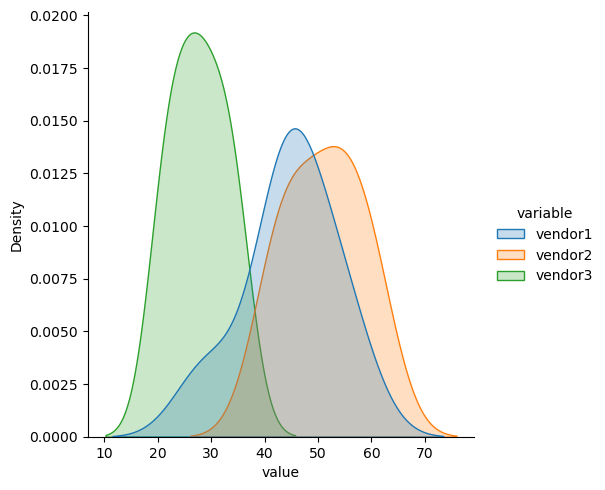

```python
# load data
vendor_scores = pd.read_excel("C:/Users/guilhermep/Documents/PgDip/Coding/Module 2/pgdip_module2_practice/Datasets/vendor_scores.xlsx")

# load seaborn for visualisation
import seaborn as sns



vendor_scores["id"] = vendor_scores.index

sns.displot(data=pd.melt(vendor_scores, id_vars="id", value_vars=["vendor1", "vendor2", "vendor3"]), x="value", hue="variable", kind="kde", fill=True)
```

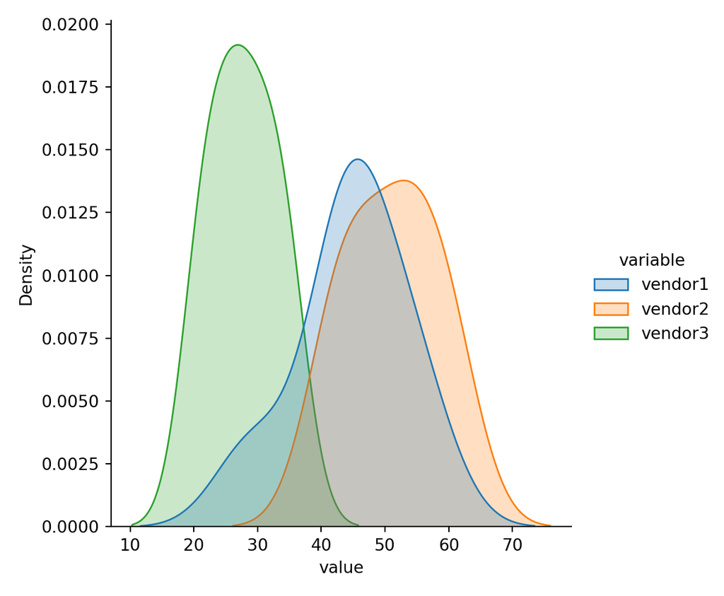

```python
plt.show()
```

```python
#
```

Compute summary statistics

```python
print("Means:")
```

```
## Means:
```

```python
pd.melt(vendor_scores, id_vars="id", value_vars=["vendor1", "vendor2", "vendor3"]).groupby("variable").mean()
```

```
##            id      value
## variable
## vendor1   3.0  44.714286
## vendor2   3.0  51.000000
## vendor3   3.0  27.714286
```

```python
print("SDs:")
```

```
## SDs:
```

```python
pd.melt(vendor_scores, id_vars="id", value_vars=["vendor1", "vendor2", "vendor3"]).groupby("variable").std()
```

```
##                 id     value
## variable
## vendor1   2.160247  8.577379
## vendor2   2.160247  7.325754
## vendor3   2.160247  5.282496
```

```python
print("95% CIs:")
```

```
## 95% CIs:
```

```python
print("Vendor 1: ", stats.t.interval(0.95, len(vendor_scores.vendor1)-1, loc=np.mean(vendor_scores.vendor1), scale=stats.sem(vendor_scores.vendor1)))
```

```
## Vendor 1:  (36.78153332654523, 52.6470381020262)
```

```python
print("Vendor 2: ", stats.t.interval(0.95, len(vendor_scores.vendor2)-1, loc=np.mean(vendor_scores.vendor2), scale=stats.sem(vendor_scores.vendor2)))
```

```
## Vendor 2:  (44.22480788212335, 57.77519211787665)
```

```python
print("Vendor 3: ", stats.t.interval(0.95, len(vendor_scores.vendor3)-1, loc=np.mean(vendor_scores.vendor3), scale=stats.sem(vendor_scores.vendor3)))
```

```
## Vendor 3:  (22.828791935417676, 32.599779493153754)
```

Compute anova

```python
stats.f_oneway(vendor_scores.vendor1,vendor_scores.vendor2,vendor_scores.vendor3)
```

```
## F_onewayResult(statistic=19.643646408839746, pvalue=2.9848866902345244e-05)
```